# CMM020 MOCK Practical Examination

## TASK 3

First check the correlation coefficient.

```r
cor(vessel$Beam,vessel$Length)
```

```
## [1] 0.9321226
```

The correlation coefficient is relatively close to 1, suggesting a strong correlation.

The data points are visualised.

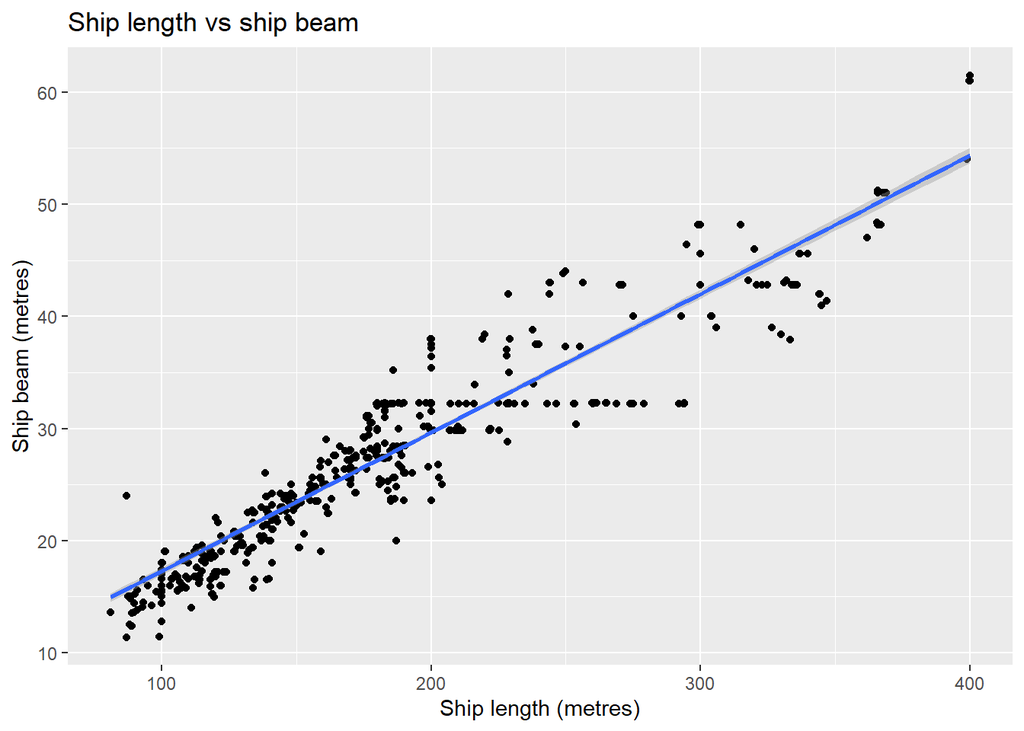

```r
p <- ggplot(vessel, aes(x=Length, y = Beam))
p <- p+geom_point()
p <- p+ geom_smooth(method="lm", formula= "y~x")
p <- p+labs( title="Ship length vs ship beam", x = "Ship length (metres)", y = "Ship beam (metres)")
p
```

The points are aligned with the line to some extent but they are relatively apart from the line for some ship lengths above 150. For points below a length of 150, the line is mainly above. There are lots of lengths for a ship beam of around 32 (a horizontal line pattern).

Obtaining the linear model.

```r
lm.output <- lm(formula = vessel$Beam ~ vessel$Length)
summary(lm.output)
```

```
##
## Call:
## lm(formula = vessel$Beam ~ vessel$Length)
##
## Residuals:
##     Min      1Q  Median      3Q     Max
## -9.0691 -1.9670 -0.2639  1.8466  8.8263
##
## Coefficients:
##               Estimate Std. Error t value Pr(>|t|)
## (Intercept)   4.933085   0.313180   15.75   <2e-16 ***
## vessel$Length 0.123537   0.001569   78.75   <2e-16 ***
## ---
## Signif. codes:  0 '***' 0.001 '**' 0.01 '*' 0.05 '.' 0.1 ' ' 1
##
## Residual standard error: 3.358 on 936 degrees of freedom
## Multiple R-squared:  0.8689, Adjusted R-squared:  0.8687
## F-statistic:  6201 on 1 and 936 DF,  p-value: < 2.2e-16
```

The model is Beam = 4.9331 + 0.1235 * Length.

The distribution of residuals may be plotted to check whether it is close to normal.

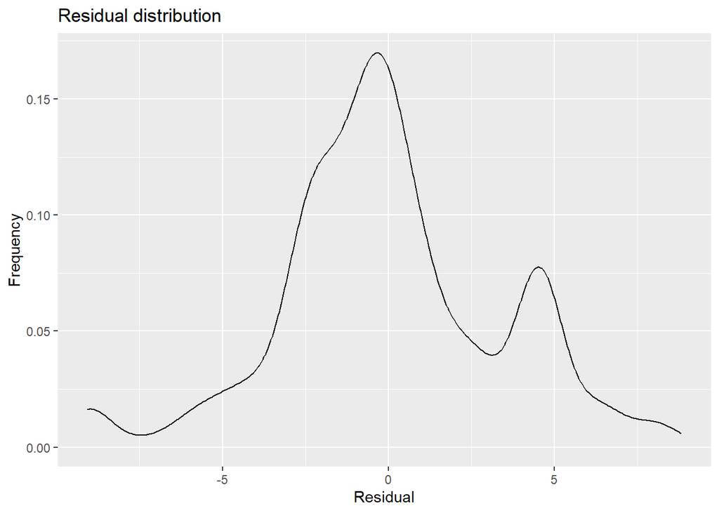

```r
r <-  lm.output$residuals
re <- data.frame(res=r)
p <- ggplot(re, aes(res))
#p <- p+geom_histogram(colour="wheat", fill="wheat", bins=40 , aes(y=..density..))
p <-  p+geom_density()
p <- p+labs( title="Residual distribution", x = "Residual", y = "Frequency")
p
```

The plot shows that the distribution of residuals is not entirely normal.

Q-Q plot

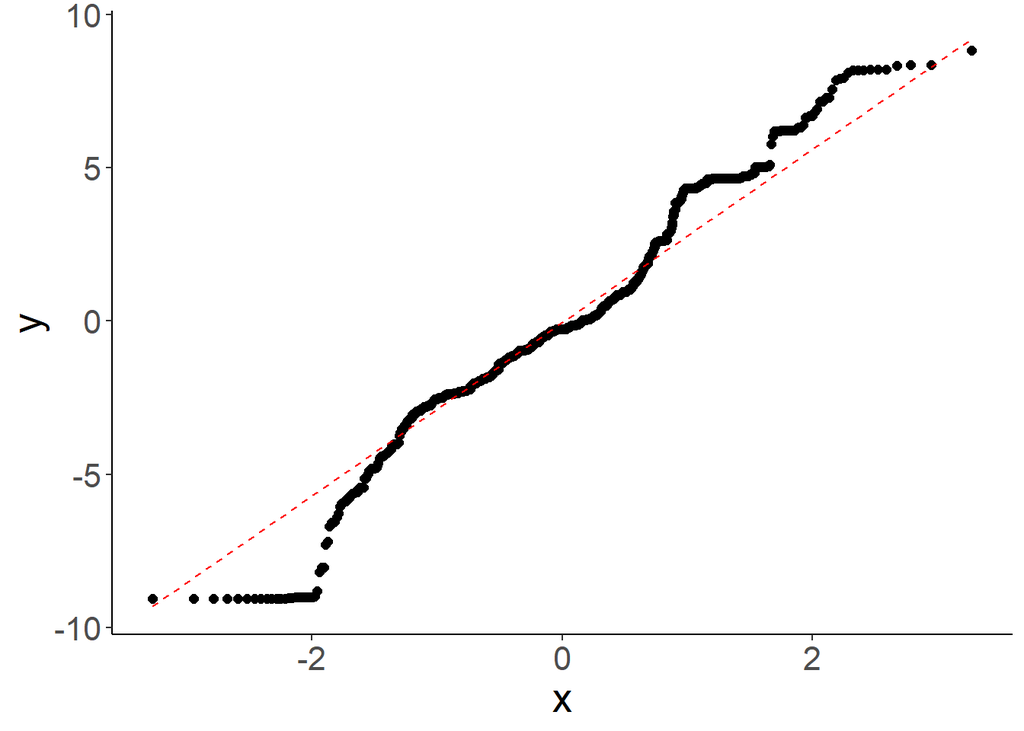

```r
lmData <-
data.frame(residuals = lm.output$residuals,
                Length= vessel$Length,
                Beam = vessel$Beam)

p <- ggplot(lmData, aes(sample = residuals))
p <- p + stat_qq(size=2) +
stat_qq_line( alpha = 0.9, color = "red",
linetype = "dashed")
p <- p +  theme_classic()
p <- p + theme(text = element_text(size = 20))
p
```

We can see that the residuals are not normally distributed in this case. Some points are far from the line.

```r
shapiro.test(lmData$residuals)
```

```
##
##  Shapiro-Wilk normality test
##
## data:  lmData$residuals
## W = 0.97114, p-value = 1.09e-12
```

The p-value is smaller than 0.05, indicating that it is not reasonable to assume that the residuals are normally distributed.

### Multiple linear regression

```r
lm.output2 <- lm(Beam ~Length+Draft, data = vessel)
summary(lm.output2)
```

```
##
## Call:
## lm(formula = Beam ~ Length + Draft, data = vessel)
##
## Residuals:
##      Min       1Q   Median       3Q      Max
## -20.9733  -1.5222  -0.3206   1.8189  10.8357
##
## Coefficients:
##             Estimate Std. Error t value Pr(>|t|)
## (Intercept) 2.090766   0.323075   6.471 1.56e-10 ***
## Length      0.098004   0.002055  47.694  < 2e-16 ***
## Draft       0.751396   0.044888  16.739  < 2e-16 ***
## ---
## Signif. codes:  0 '***' 0.001 '**' 0.01 '*' 0.05 '.' 0.1 ' ' 1
##
## Residual standard error: 2.947 on 935 degrees of freedom
## Multiple R-squared:  0.8991, Adjusted R-squared:  0.8989
## F-statistic:  4165 on 2 and 935 DF,  p-value: < 2.2e-16
```

The equation is

Beam = 2.090766 + 0.098004 * Length + 0.751396 * Draft

The residual standard error has decreased and the adjusted R-squared has increased. The intercept and slopes are significant, suggesting this is a better model.